# Flux at Collar Transects

Chloe

## Plots and Analysis

Average Flux of Each Site

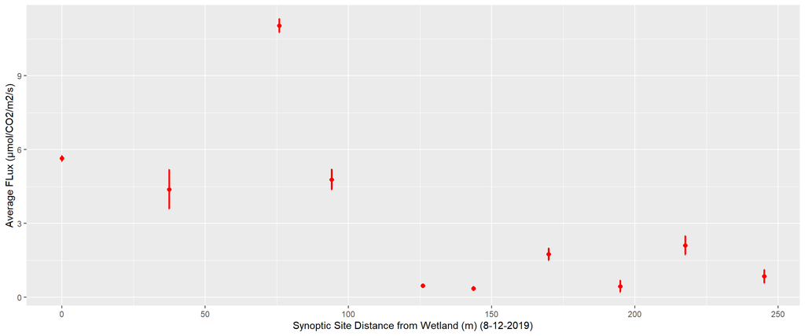

Average Flux of Each Site

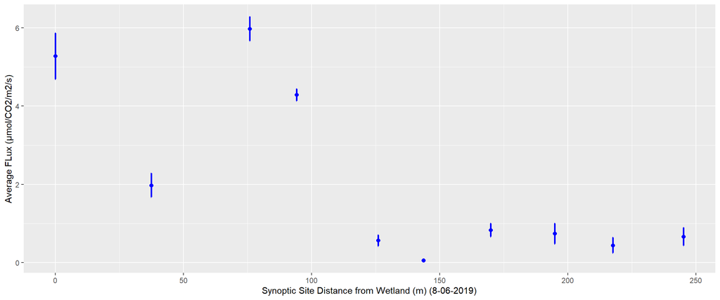

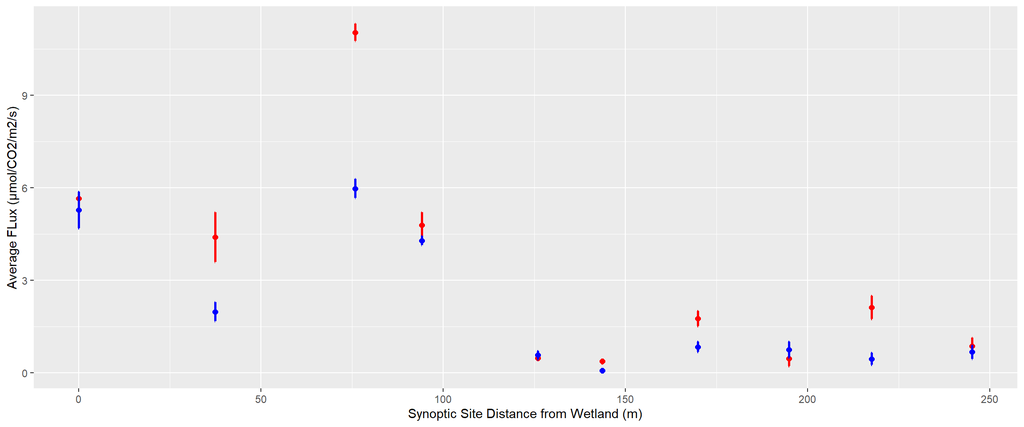

combine

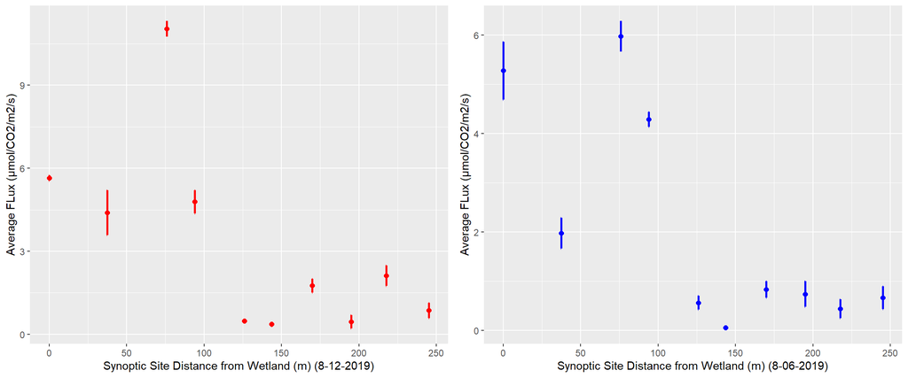

Average Flux of Each Site 7-31-2019

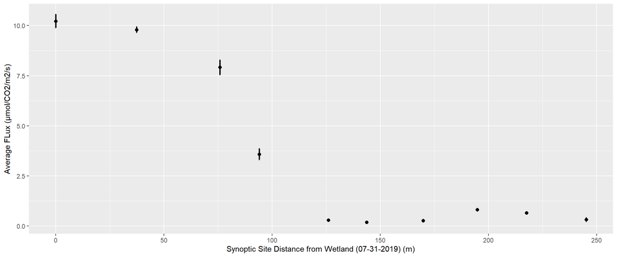

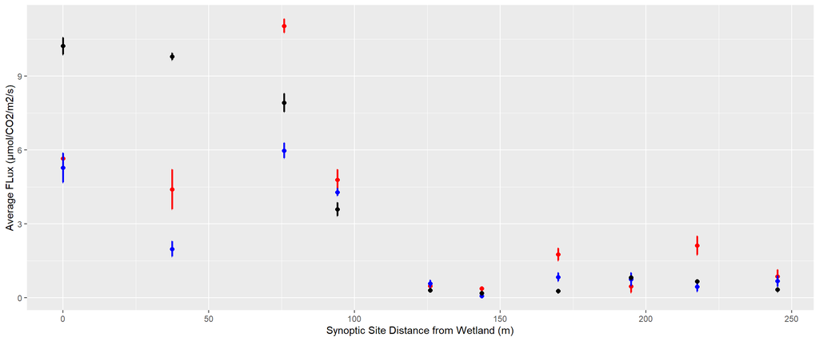

Average Flux of Each Site

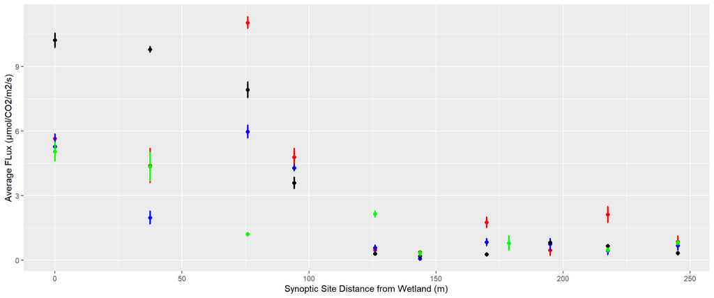

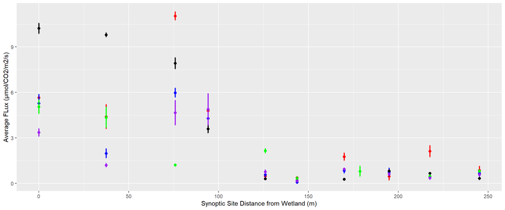

Individual Synoptic days

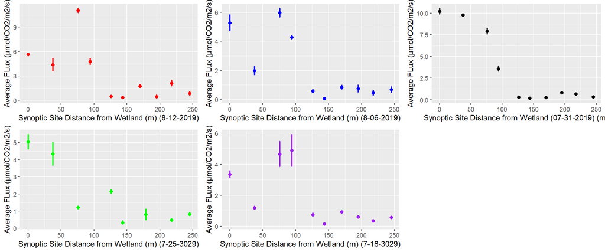

Combined Synoptic Day Flux Data

|  | Flux0812 | Flux0806 | Flux0731 | Flux0718 |
| --- | --- | --- | --- | --- |
| syn35 | 5.646667 | 5.2775 | 10.2250 | 3.3500 |
| syn29 | 4.392500 | 1.9775 | 9.7925 | 1.1950 |
| syn23 | 11.040000 | 5.9750 | 7.9175 | 4.6575 |
| syn20 | 4.787500 | 4.2875 | 3.5825 | 4.8800 |
| waterfall | 0.475000 | 0.5650 | 0.2925 | 0.7575 |
| syn14 | 0.362500 | 0.0600 | 0.1800 | 0.1525 |
| syn11 | 1.755000 | 0.8350 | 0.2650 | 0.9300 |
| syn8 | 0.452500 | 0.7400 | 0.8125 | 0.6200 |
| syn 5 | 2.115000 | 0.4425 | 0.6525 | 0.3600 |
| syn1 | 0.857500 | 0.6650 | 0.3225 | 0.5780 |

Averages and Standard Deviation of Synoptic Locations of 4 Synoptic Days

|  | AverageFlux | StdDev | dis |
| --- | --- | --- | --- |
| syn35 | 6.124792 | 2.9130559 | 0.0 |
| syn29 | 4.339375 | 3.8817926 | 37.4 |
| syn23 | 7.397500 | 2.7730436 | 75.9 |
| syn20 | 4.384375 | 0.5945705 | 94.1 |
| waterfall | 0.522500 | 0.1933800 | 126.0 |
| syn14 | 0.188750 | 0.1266968 | 143.7 |
| syn11 | 0.946250 | 0.6139541 | 169.9 |
| syn8 | 0.656250 | 0.1573279 | 194.9 |
| syn 5 | 0.892500 | 0.8242497 | 217.6 |
| syn1 | 0.605750 | 0.2220280 | 245.2 |

Synoptic Fluxes combined with Average and Standard Deviation of Synoptic Locations of 4 Synoptic Days

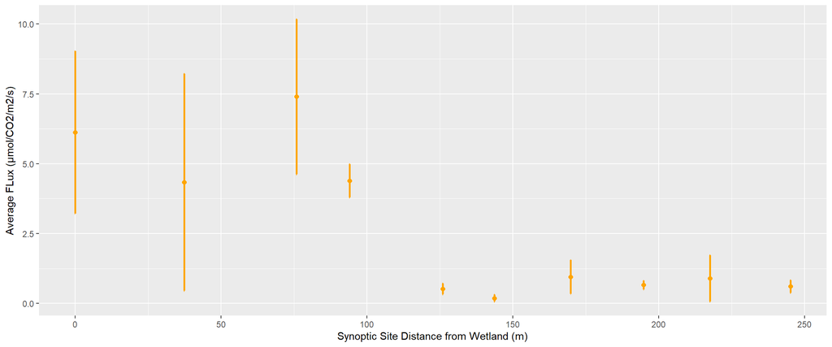

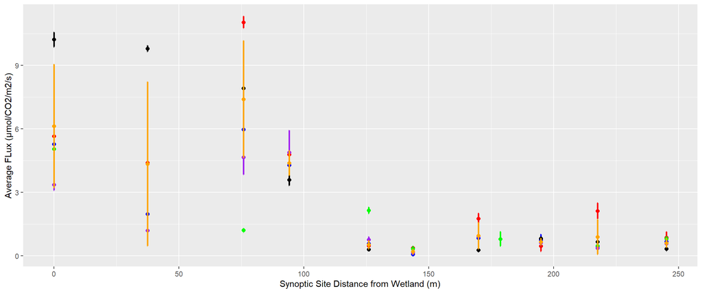

Flux of Collars 7-16-2019

col1.1

| DateTime | Flux_eos2 |
| --- | --- |
| 2019-07-16 13:15:00 | 1.11 |
| 2019-07-16 13:20:00 | 1.14 |
| 2019-07-16 13:25:00 | 1.12 |
| 2019-07-16 13:30:00 | 1.10 |
| 2019-07-16 13:35:00 | 1.20 |
| 2019-07-16 13:40:00 | 1.21 |

col2.1

| DateTime | Flux_eos2 |
| --- | --- |
| 2019-07-16 13:55:00 | 0.64 |
| 2019-07-16 14:00:00 | 0.40 |
| 2019-07-16 14:05:00 | 0.45 |
| 2019-07-16 14:10:00 | 0.46 |
| 2019-07-16 14:15:00 | 0.47 |

col3.1

| DateTime | Flux_eos2 |
| --- | --- |
| 2019-07-16 14:40:00 | 1.46 |
| 2019-07-16 14:45:00 | 1.07 |
| 2019-07-16 14:50:00 | 0.86 |
| 2019-07-16 14:55:00 | 0.70 |
| 2019-07-16 15:00:00 | 0.61 |

col4.1

| DateTime | Flux_eos2 |
| --- | --- |
| 2019-07-16 15:25:00 | 0.38 |
| 2019-07-16 15:30:00 | 0.40 |
| 2019-07-16 15:35:00 | 0.29 |
| 2019-07-16 15:40:00 | 0.19 |
| 2019-07-16 15:45:00 | 0.11 |

col5.1

| DateTime | Flux_eos2 |
| --- | --- |
| 2019-07-16 16:20:00 | 1.66 |
| 2019-07-16 16:25:00 | 1.73 |
| 2019-07-16 16:30:00 | 1.58 |
| 2019-07-16 16:35:00 | 1.67 |
| 2019-07-16 16:40:00 | 1.70 |

col6.1

| DateTime | Flux_eos2 |
| --- | --- |
| 2019-07-16 17:00:00 | 0.03 |
| 2019-07-16 17:05:00 | 0.03 |
| 2019-07-16 17:10:00 | 0.05 |
| 2019-07-16 17:15:00 | 0.08 |
| 2019-07-16 17:20:00 | 0.08 |
| 2019-07-16 17:25:00 | 0.08 |

col7.1

| DateTime | Flux_eos2 |
| --- | --- |
| 2019-07-16 17:40:00 | 2.72 |
| 2019-07-16 17:45:00 | 1.40 |
| 2019-07-16 17:50:00 | 1.09 |
| 2019-07-16 17:55:00 | 0.91 |
| 2019-07-16 18:00:00 | 0.79 |
| 2019-07-16 18:05:00 | 0.87 |

Average Flux of Each Site

|  | AverageFlux |
| --- | --- |
| col1.1 | 1.1466667 |
| col2.1 | 0.4840000 |
| col3.1 | 0.9400000 |
| col4.1 | 0.2740000 |
| col5.1 | 1.6680000 |
| col6.1 | 0.0583333 |
| col7.1 | 1.2485714 |

|  | StdDev |
| --- | --- |
| col1.1 | 0.0471876 |
| col2.1 | 0.0912688 |
| col3.1 | 0.3391902 |
| col4.1 | 0.1238144 |
| col5.1 | 0.0563028 |
| col6.1 | 0.0248328 |
| col7.1 | 0.6788085 |

collars 7-16-2019

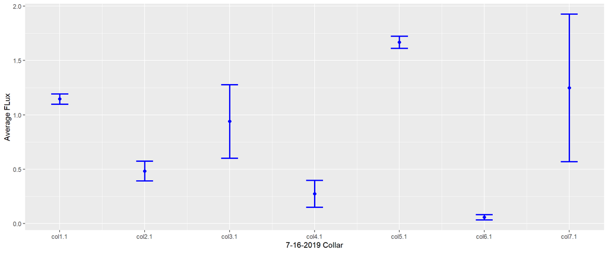

Flux of Collars 7-22-2019

col1.2

| DateTime | Flux_eos2 |
| --- | --- |
| 2019-07-22 19:25:00 | 0.97 |
| 2019-07-22 19:30:00 | 1.23 |
| 2019-07-22 19:35:00 | 1.22 |
| 2019-07-22 19:40:00 | 1.38 |

col2.2

| DateTime | Flux_eos2 |
| --- | --- |
| 2019-07-22 19:05:00 | 0.40 |
| 2019-07-22 19:10:00 | 0.67 |
| 2019-07-22 19:15:00 | 0.69 |
| 2019-07-22 19:20:00 | 0.96 |

col3.2

| DateTime | Flux_eos2 |
| --- | --- |
| 2019-07-22 18:35:00 | 2.50 |
| 2019-07-22 18:40:00 | 1.80 |
| 2019-07-22 18:45:00 | 1.41 |
| 2019-07-22 18:50:00 | 1.13 |
| 2019-07-22 18:55:00 | 1.01 |

col4.2

| DateTime | Flux_eos2 |
| --- | --- |
| 2019-07-22 18:10:00 | 0.26 |
| 2019-07-22 18:15:00 | 0.20 |
| 2019-07-22 18:20:00 | 0.15 |
| 2019-07-22 18:25:00 | 0.21 |

col5.2

| DateTime | Flux_eos2 |
| --- | --- |
| 2019-07-22 15:30:00 | 2.35 |
| 2019-07-22 15:35:00 | 2.35 |
| 2019-07-22 15:40:00 | 2.43 |
| 2019-07-22 15:45:00 | 2.43 |

col6.2

| DateTime | Flux_eos2 |
| --- | --- |
| 2019-07-22 15:55:00 | 0.14 |
| 2019-07-22 16:00:00 | 0.15 |
| 2019-07-22 16:05:00 | 0.11 |
| 2019-07-22 16:10:00 | 0.25 |

col7.2

| DateTime | Flux_eos2 |
| --- | --- |
| 2019-07-22 16:45:00 | 1.32 |
| 2019-07-22 16:50:00 | 1.05 |
| 2019-07-22 16:55:00 | 1.11 |
| 2019-07-22 17:00:00 | 0.82 |

col8.2

| DateTime | Flux_eos2 |
| --- | --- |
| 2019-07-22 17:15:00 | 0.90 |
| 2019-07-22 17:20:00 | 0.84 |
| 2019-07-22 17:25:00 | 0.81 |
| 2019-07-22 17:30:00 | 0.53 |

Average Flux of Each Site

|  | AverageFlux |
| --- | --- |
| col1.2 | 1.2000 |
| col2.2 | 0.6800 |
| col3.2 | 1.5700 |
| col4.2 | 0.2050 |
| col5.2 | 2.3900 |
| col6.2 | 0.1625 |
| col7.2 | 1.0750 |
| col8.2 | 0.7700 |

|  | StdDev |
| --- | --- |
| col1.2 | 0.1699019 |
| col2.2 | 0.2287648 |
| col3.2 | 0.6022043 |
| col4.2 | 0.0450925 |
| col5.2 | 0.0461880 |
| col6.2 | 0.0607591 |
| col7.2 | 0.2056696 |
| col8.2 | 0.1643168 |

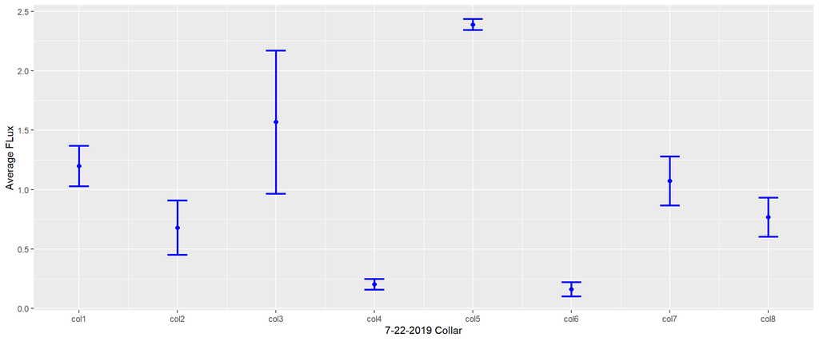

Flux of Collars 7-29-2019

col1.3

| DateTime | Flux_eos1 |
| --- | --- |
| 2019-07-29 12:10:00 | 2.86 |
| 2019-07-29 12:15:00 | 2.28 |
| 2019-07-29 12:20:00 | 1.86 |
| 2019-07-29 12:25:00 | 1.67 |

col2.3

| DateTime | Flux_eos1 |
| --- | --- |
| 2019-07-29 12:35:00 | 1.04 |
| 2019-07-29 12:40:00 | 0.74 |
| 2019-07-29 12:45:00 | 0.83 |
| 2019-07-29 12:50:00 | 0.99 |

col3.3

| DateTime | Flux_eos1 |
| --- | --- |
| 2019-07-29 13:00:00 | 0.85 |
| 2019-07-29 13:05:00 | 0.70 |
| 2019-07-29 13:10:00 | 0.64 |
| 2019-07-29 13:15:00 | 0.42 |

col4.3

| DateTime | Flux_eos1 |
| --- | --- |
| 2019-07-29 13:25:00 | 0.20 |
| 2019-07-29 13:30:00 | 0.16 |
| 2019-07-29 13:35:00 | 0.11 |
| 2019-07-29 13:40:00 | 0.22 |

col5.3

| DateTime | Flux_eos2 |
| --- | --- |
| 2019-07-29 12:30:00 | 1.72 |
| 2019-07-29 12:35:00 | 1.69 |
| 2019-07-29 12:40:00 | 1.76 |
| 2019-07-29 12:45:00 | 1.65 |
| 2019-07-29 12:50:00 | 1.47 |

col6.3

| DateTime | Flux_eos2 |
| --- | --- |
| 2019-07-29 13:00:00 | 0.34 |
| 2019-07-29 13:05:00 | 0.33 |
| 2019-07-29 13:10:00 | 0.25 |
| 2019-07-29 13:15:00 | 0.20 |
| 2019-07-29 13:20:00 | 0.27 |

col7.3

| DateTime | Flux_eos2 |
| --- | --- |
| 2019-07-29 13:30:00 | 1.20 |
| 2019-07-29 13:35:00 | 1.15 |
| 2019-07-29 13:40:00 | 1.30 |
| 2019-07-29 13:45:00 | 1.43 |

col8.3

| DateTime | Flux_eos2 |
| --- | --- |
| 2019-07-29 14:00:00 | 0.91 |
| 2019-07-29 14:05:00 | 0.81 |
| 2019-07-29 14:10:00 | 0.74 |
| 2019-07-29 14:15:00 | 0.93 |

Average Flux of Each Site

|  | AverageFlux |
| --- | --- |
| col1.3 | 2.1675 |
| col2.3 | 0.9000 |
| col3.3 | 0.6525 |
| col4.3 | 0.1725 |
| col5.3 | 1.6580 |
| col6.3 | 0.2780 |
| col7.3 | 1.2700 |
| col8.3 | 0.8475 |

|  | StdDev |
| --- | --- |
| col1.3 | 0.5273440 |
| col2.3 | 0.1392839 |
| col3.3 | 0.1783956 |
| col4.3 | 0.0485627 |
| col5.3 | 0.1125611 |
| col6.3 | 0.0580517 |
| col7.3 | 0.1235584 |
| col8.3 | 0.0888351 |

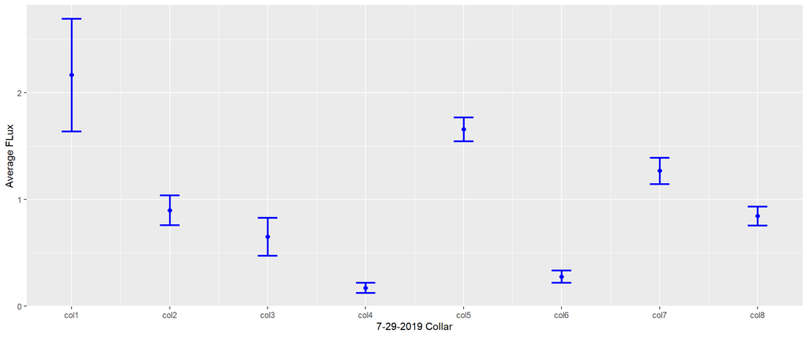

### Flux of Collars

col1.4

| DateTime | Flux_eos2 |
| --- | --- |
| 2019-08-01 17:25:00 | 0.48 |
| 2019-08-01 17:30:00 | 1.73 |
| 2019-08-01 17:35:00 | 1.96 |
| 2019-08-01 17:40:00 | 1.28 |

col2.4

| DateTime | Flux_eos2 |
| --- | --- |
| 2019-08-01 17:05:00 | 0.60 |
| 2019-08-01 17:10:00 | 0.76 |
| 2019-08-01 17:15:00 | 0.79 |
| 2019-08-01 17:20:00 | 0.92 |

col3.4

| DateTime | Flux_eos2 |
| --- | --- |
| 2019-08-01 15:40:00 | 0.62 |
| 2019-08-01 15:45:00 | 0.72 |
| 2019-08-01 15:50:00 | 0.70 |

col4.4

| DateTime | Flux_eos2 |
| --- | --- |
| 2019-08-01 18:05:00 | 0.48 |
| 2019-08-01 18:10:00 | 0.40 |
| 2019-08-01 18:15:00 | 0.18 |
| 2019-08-01 18:20:00 | 0.82 |

col5.4

| DateTime | Flux_eos2 |
| --- | --- |
| 2019-08-01 15:00:00 | 0.76 |
| 2019-08-01 15:05:00 | 0.98 |
| 2019-08-01 15:10:00 | 1.34 |
| 2019-08-01 15:15:00 | 1.38 |

col6.4

| DateTime | Flux_eos2 |
| --- | --- |
| 2019-08-01 15:20:00 | 1.06 |
| 2019-08-01 15:25:00 | 0.79 |
| 2019-08-01 15:30:00 | 0.53 |
| 2019-08-01 15:35:00 | 0.27 |

col7.4

| DateTime | Flux_eos2 |
| --- | --- |
| 2019-08-01 15:40:00 | 0.62 |
| 2019-08-01 15:45:00 | 0.72 |
| 2019-08-01 15:50:00 | 0.70 |

col8.4

| DateTime | Flux_eos2 |
| --- | --- |
| 2019-08-01 16:05:00 | 0.48 |
| 2019-08-01 16:10:00 | 0.56 |
| 2019-08-01 16:15:00 | 0.46 |
| 2019-08-01 16:20:00 | 0.49 |

Average Flux of Each Site

|  | AverageFlux |
| --- | --- |
| col1.4 | 1.3625 |
| col2.4 | 0.7675 |
| col3.4 | 0.6800 |
| col4.4 | 0.4700 |
| col5.4 | 1.1150 |
| col6.4 | 0.6625 |
| col7.4 | 0.6800 |
| col8.4 | 0.4975 |

|  | StdDev |
| --- | --- |
| col1.4 | 0.6526038 |
| col2.4 | 0.1314978 |
| col3.4 | 0.0529150 |
| col4.4 | 0.2655811 |
| col5.4 | 0.2972653 |
| col6.4 | 0.3395463 |
| col7.4 | 0.0529150 |
| col8.4 | 0.0434933 |

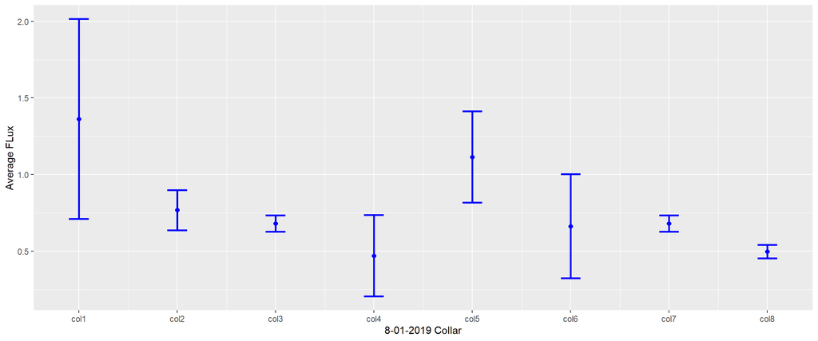

Flux of Collars 8-05-2019

col1.5

| DateTime | Flux_eos2 |
| --- | --- |
| 2019-08-05 17:15:00 | 1.03 |
| 2019-08-05 17:20:00 | 0.77 |
| 2019-08-05 17:25:00 | 1.18 |
| 2019-08-05 17:30:00 | 2.19 |

col2.5

| DateTime | Flux_eos2 |
| --- | --- |
| 2019-08-05 17:40:00 | 0.61 |
| 2019-08-05 17:45:00 | 0.52 |
| 2019-08-05 17:50:00 | 0.57 |
| 2019-08-05 17:55:00 | 1.01 |

col3.5

| DateTime | Flux_eos2 |
| --- | --- |
| 2019-08-05 18:00:00 | 0.82 |
| 2019-08-05 18:05:00 | 0.70 |
| 2019-08-05 18:10:00 | 0.60 |

col4.5

| DateTime | Flux_eos2 |
| --- | --- |
| 2019-08-05 18:25:00 | 0.08 |
| 2019-08-05 18:30:00 | 0.10 |
| 2019-08-05 18:35:00 | 0.13 |

col5.5

| DateTime | Flux_eos2 |
| --- | --- |
| 2019-08-05 16:40:00 | 0.70 |
| 2019-08-05 16:45:00 | 0.98 |
| 2019-08-05 16:50:00 | 0.99 |
| 2019-08-05 16:55:00 | 0.56 |

col6.5

| DateTime | Flux_eos2 |
| --- | --- |
| 2019-08-05 15:40:00 | 0.19 |
| 2019-08-05 15:45:00 | 0.30 |
| 2019-08-05 15:50:00 | 0.26 |
| 2019-08-05 15:55:00 | 0.22 |

col7.5

| DateTime | Flux_eos2 |
| --- | --- |
| 2019-08-05 16:00:00 | 0.94 |
| 2019-08-05 16:05:00 | 0.89 |
| 2019-08-05 16:10:00 | 0.96 |
| 2019-08-05 16:15:00 | 1.75 |

col8.5

| DateTime | Flux_eos2 |
| --- | --- |
| 2019-08-05 16:20:00 | 0.39 |
| 2019-08-05 16:25:00 | 0.58 |
| 2019-08-05 16:30:00 | 0.61 |
| 2019-08-05 16:35:00 | 0.24 |

Average Flux of Each Site

|  | AverageFlux |
| --- | --- |
| col1.5 | 1.2925000 |
| col2.5 | 0.6775000 |
| col3.5 | 0.7066667 |
| col4.5 | 0.1033333 |
| col5.5 | 0.8075000 |
| col6.5 | 0.2425000 |
| col7.5 | 1.1350000 |
| col8.5 | 0.4550000 |

|  | StdDev |
| --- | --- |
| col1.5 | 0.6218454 |
| col2.5 | 0.2247035 |
| col3.5 | 0.1101514 |
| col4.5 | 0.0251661 |
| col5.5 | 0.2128184 |
| col6.5 | 0.0478714 |
| col7.5 | 0.4110556 |
| col8.5 | 0.1733013 |

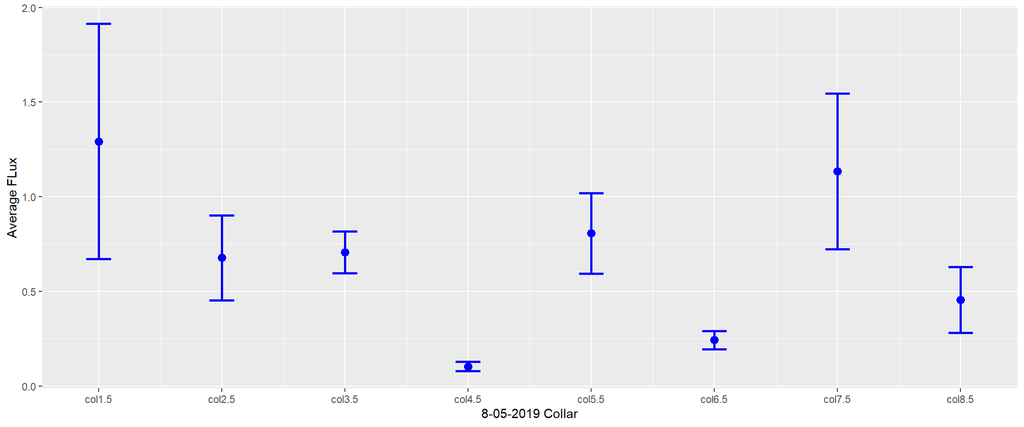

Flux of Collars 8-08-2019

col1.6

| DateTime | Flux_eos2 |
| --- | --- |
| 2019-08-08 12:50:00 | 1.38 |
| 2019-08-08 12:55:00 | 1.49 |
| 2019-08-08 13:00:00 | 1.49 |

col2.6

| DateTime | Flux_eos2 |
| --- | --- |
| 2019-08-08 13:10:00 | 0.52 |
| 2019-08-08 13:15:00 | 0.47 |
| 2019-08-08 13:20:00 | 0.50 |

col3.6

| DateTime | Flux_eos2 |
| --- | --- |
| 2019-08-08 13:30:00 | 1.54 |
| 2019-08-08 13:35:00 | 1.03 |
| 2019-08-08 13:40:00 | 1.17 |
| 2019-08-08 13:45:00 | 0.23 |

col4.6

| DateTime | Flux_eos2 |
| --- | --- |
| 2019-08-08 13:50:00 | 0.43 |
| 2019-08-08 13:55:00 | 0.29 |
| 2019-08-08 14:00:00 | 0.23 |
| 2019-08-08 14:05:00 | 0.20 |

col5.6

| DateTime | Flux_eos2 |
| --- | --- |
| 2019-08-08 11:20:00 | 0.65 |
| 2019-08-08 11:25:00 | 0.80 |
| 2019-08-08 11:30:00 | 0.75 |
| 2019-08-08 11:35:00 | 0.31 |

col6.6

| DateTime | Flux_eos2 |
| --- | --- |
| 2019-08-08 11:40:00 | 0.34 |
| 2019-08-08 11:45:00 | 0.40 |
| 2019-08-08 11:50:00 | 0.41 |
| 2019-08-08 11:55:00 | 0.17 |

col7.6

| DateTime | Flux_eos2 |
| --- | --- |
| 2019-08-08 12:00:00 | 0.54 |
| 2019-08-08 12:05:00 | 0.53 |
| 2019-08-08 12:10:00 | 0.61 |
| 2019-08-08 12:15:00 | 0.20 |

col8.6

| DateTime | Flux_eos2 |
| --- | --- |
| 2019-08-08 12:20:00 | 0.34 |
| 2019-08-08 12:25:00 | 0.39 |
| 2019-08-08 12:30:00 | 0.37 |
| 2019-08-08 12:35:00 | 0.40 |

Average Flux of Each Site

|  | AverageFlux |
| --- | --- |
| col1.6 | 1.4533333 |
| col2.6 | 0.4966667 |
| col3.6 | 0.9925000 |
| col4.6 | 0.2875000 |
| col5.6 | 0.6275000 |
| col6.6 | 0.3300000 |
| col7.6 | 0.4700000 |
| col8.6 | 0.3750000 |

|  | StdDev |
| --- | --- |
| col1.6 | 0.0635085 |
| col2.6 | 0.0251661 |
| col3.6 | 0.5519888 |
| col4.6 | 0.1021029 |
| col5.6 | 0.2206619 |
| col6.6 | 0.1110555 |
| col7.6 | 0.1834848 |
| col8.6 | 0.0264575 |

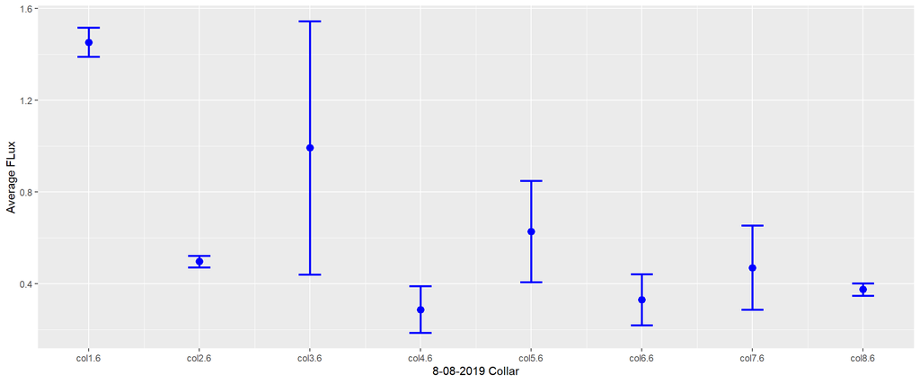

col1.7

| DateTime | Flux_eos2 |
| --- | --- |
| 2019-08-13 10:45:00 | 0.64 |
| 2019-08-13 10:50:00 | 0.72 |
| 2019-08-13 10:55:00 | 0.86 |
| 2019-08-13 11:00:00 | 0.99 |

col2.7

| DateTime | Flux_eos2 |
| --- | --- |
| 2019-08-13 11:10:00 | 0.33 |
| 2019-08-13 11:15:00 | 0.24 |
| 2019-08-13 11:20:00 | 0.21 |
| 2019-08-13 11:25:00 | 0.26 |

col3.7

| DateTime | Flux_eos2 |
| --- | --- |
| 2019-08-13 11:35:00 | 0.52 |
| 2019-08-13 11:40:00 | 0.45 |
| 2019-08-13 11:45:00 | 0.39 |
| 2019-08-13 11:50:00 | 0.25 |

col4.7

| DateTime | Flux_eos2 |
| --- | --- |
| 2019-08-13 11:55:00 | 0.59 |
| 2019-08-13 12:00:00 | 0.44 |
| 2019-08-13 12:05:00 | 0.38 |
| 2019-08-13 12:10:00 | 0.42 |

col5.7

| DateTime | Flux_eos1 |
| --- | --- |
| 2019-08-13 10:45:00 | 0.50 |
| 2019-08-13 10:50:00 | 0.61 |
| 2019-08-13 10:55:00 | 0.66 |
| 2019-08-13 11:00:00 | 0.31 |

col6.7

| DateTime | Flux_eos1 |
| --- | --- |
| 2019-08-13 11:05:00 | 0.36 |
| 2019-08-13 11:10:00 | 0.38 |
| 2019-08-13 11:15:00 | 0.34 |
| 2019-08-13 11:20:00 | 0.21 |

col7.7

| DateTime | Flux_eos1 |
| --- | --- |
| 2019-08-13 11:25:00 | 0.35 |
| 2019-08-13 11:30:00 | 0.38 |
| 2019-08-13 11:35:00 | 0.42 |
| 2019-08-13 11:40:00 | 0.07 |

col8.7

| DateTime | Flux_eos1 |
| --- | --- |
| 2019-08-13 11:45:00 | 0.39 |
| 2019-08-13 11:50:00 | 0.51 |
| 2019-08-13 11:55:00 | 0.55 |
| 2019-08-13 12:00:00 | 0.32 |

Average Flux of Each Site

|  | AverageFlux |
| --- | --- |
| col1.7 | 0.8025 |
| col2.7 | 0.2600 |
| col3.7 | 0.4025 |
| col4.7 | 0.4575 |
| col5.7 | 0.5200 |
| col6.7 | 0.3225 |
| col7.7 | 0.3050 |
| col8.7 | 0.4425 |

|  | StdDev |
| --- | --- |
| col1.7 | 0.1545693 |
| col2.7 | 0.0509902 |
| col3.7 | 0.1147098 |
| col4.7 | 0.0917878 |
| col5.7 | 0.1551344 |
| col6.7 | 0.0767572 |
| col7.7 | 0.1592692 |
| col8.7 | 0.1062623 |

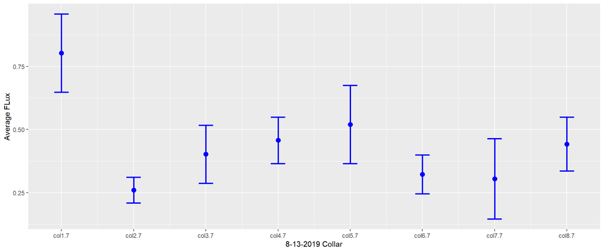

[figure not shown]

All transect days

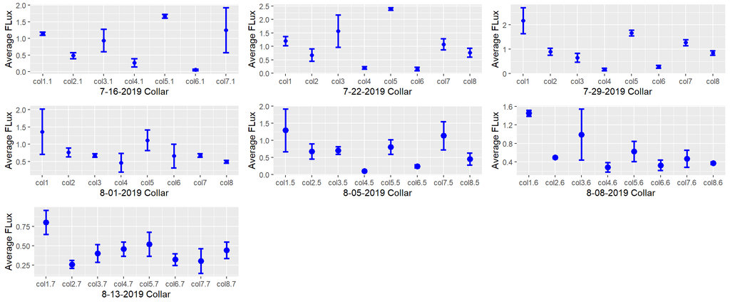

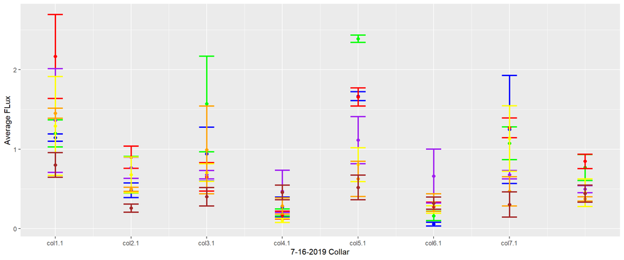

Average and standard deviation of each transect day at each collar

| col1 | col2 | col3 | col4 | col5 | col6 | col7 | col8 |
| --- | --- | --- | --- | --- | --- | --- | --- |
| 1.146667 | 0.4840000 | 0.9400000 | 0.2740000 | 1.6680 | 0.0583333 | 1.248571 | 0.7700 |
| 1.200000 | 0.6800000 | 1.5700000 | 0.2050000 | 2.3900 | 0.1625000 | 1.075000 | 0.7700 |
| 2.167500 | 0.9000000 | 0.6525000 | 0.1725000 | 1.6580 | 0.2780000 | 1.270000 | 0.8475 |
| 1.362500 | 0.7675000 | 0.6800000 | 0.4700000 | 1.1150 | 0.6625000 | 0.680000 | 0.4975 |
| 1.292500 | 0.6775000 | 0.7066667 | 0.1033333 | 0.8075 | 0.2425000 | 1.135000 | 0.4550 |
| 1.453333 | 0.4966667 | 0.9925000 | 0.2875000 | 0.6275 | 0.3300000 | 0.470000 | 0.3750 |

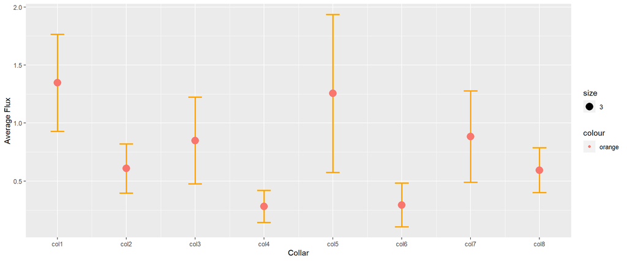

Collar fluxes by date

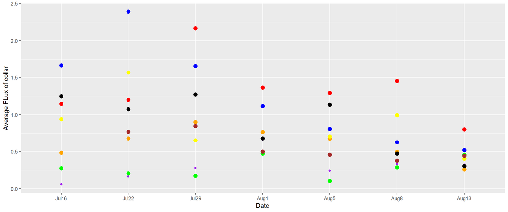

Transect near stream- Blues- lightest blue = col1 (least water) to col4 darkest blue (most water) Transect near spring- Darkest Green col5 (most water), lightest green col8 (least water)

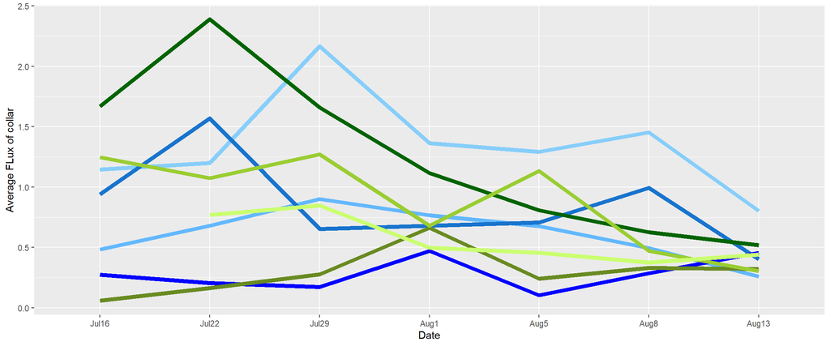

Green is eos2 which was in soil beside flotation at eos1.

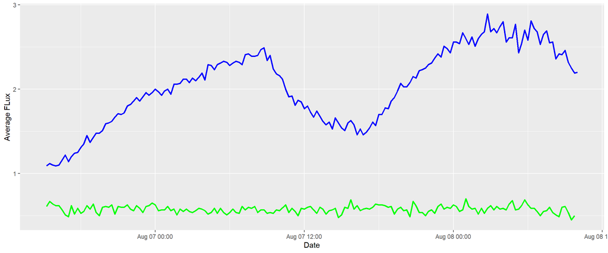

Blue is Flux from floatation and red is flux from collar 1 from 15:00 on Aug12 to 10:00 Aug13th

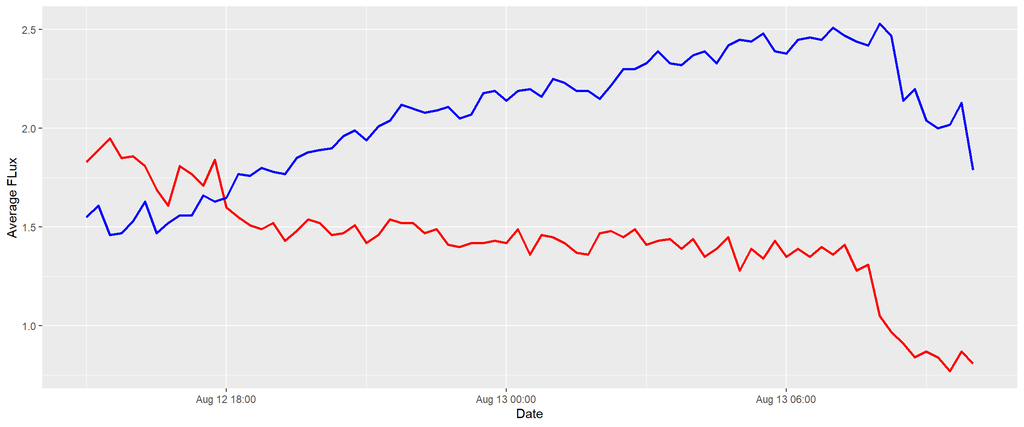

Blue is Flux from floatation and purple is flux in far wetland from 16:00 on Jul23 to 11:00 Jul25

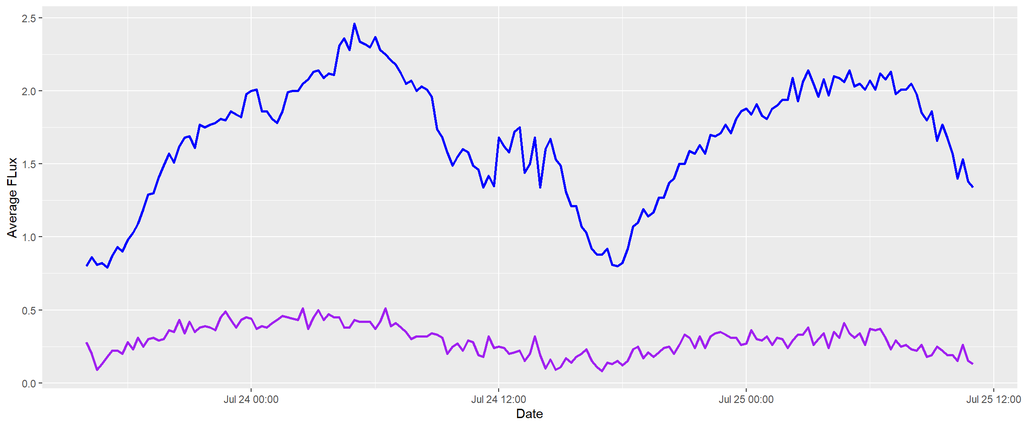

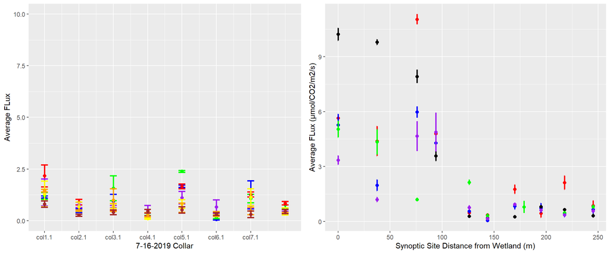